# Trab 01 - Análise Multivariada

Análise da Poluição do Ar nos EUA utilizando as ferramentas: PCA, TSNE e MDS

Fernando Pires dos Santos

# 1 Introdução

O dataset a seguir nos informa a poluição do ar em diversas cidades dos EUA. Além disso nos da outras variáveis climáticas e da ecologia humuna que utilizaremos para tentar responder a seguinte pergunta: Quais ou como os aspectos do clima e da ecologia humana, medidos pelas outras seis variáveis, influenciam a poluição?

PS: Além das variáveis originais incrementaremos nosso dataset para ver se a localização geográfica influencia a poluição.

Antes de iniciarmos um pequeno resumo de nosso dataset.

## 1.1 Resumo dados

O dataset possui dados de poluição do ar de 41 cidades dos EUA e possui informação sobre 7 variáveis listadas a seguir.

> **SO2:** *Teor de SO2 (dióxido de enxofre) do ar em microgramas por metro cúbico.*  
> **temp:** *temperatura média anual em Fahrenheit.*  
> **manu:** *número de empresas manufatureiras que empregam 20 ou mais trabalhadores.*  
> **popul:** *tamanho da população (censo de 1970); em milhares.*  
> **wind:** *velocidade média anual do vento em milhas por hora.*  
> **precip:** *precipitação média anual em polegadas.*  
> **predays:** *número médio de dias com precipitação por ano.*

Ao longo do relatório poderemos nos referir a cada variável por seu nome ou sua descrição.

# 2 Dados

## 2.1 Tabela com os dados

```r
dt = read.csv2("aula_02/usairpollution.csv", sep =';', header=T)
dt = rename(dt,city = X,)
head(dt,10)
```

|  | city | SO2 | temp | manu | popul | wind | precip | predays |
| --- | --- | --- | --- | --- | --- | --- | --- | --- |
| 1 | Albany | 46 | 47.6 | 44 | 116 | 8.8 | 33.36 | 135 |
| 2 | Albuquerque | 11 | 56.8 | 46 | 244 | 8.9 | 7.77 | 58 |
| 3 | Atlanta | 24 | 61.5 | 368 | 497 | 9.1 | 48.34 | 115 |
| 4 | Baltimore | 47 | 55.0 | 625 | 905 | 9.6 | 41.31 | 111 |
| 5 | Buffalo | 11 | 47.1 | 391 | 463 | 12.4 | 36.11 | 166 |
| 6 | Charleston | 31 | 55.2 | 35 | 71 | 6.5 | 40.75 | 148 |
| 7 | Chicago | 110 | 50.6 | 3344 | 3369 | 10.4 | 34.44 | 122 |
| 8 | Cincinnati | 23 | 54.0 | 462 | 453 | 7.1 | 39.04 | 132 |
| 9 | Cleveland | 65 | 49.7 | 1007 | 751 | 10.9 | 34.99 | 155 |
| 10 | Columbus | 26 | 51.5 | 266 | 540 | 8.6 | 37.01 | 134 |

## 2.2 Estrutura dos dados

```r
str(dt)
```

```
'data.frame':   41 obs. of  8 variables:
 $ city   : chr  "Albany" "Albuquerque" "Atlanta" "Baltimore" ...
 $ SO2    : int  46 11 24 47 11 31 110 23 65 26 ...
 $ temp   : num  47.6 56.8 61.5 55 47.1 55.2 50.6 54 49.7 51.5 ...
 $ manu   : int  44 46 368 625 391 35 3344 462 1007 266 ...
 $ popul  : int  116 244 497 905 463 71 3369 453 751 540 ...
 $ wind   : num  8.8 8.9 9.1 9.6 12.4 6.5 10.4 7.1 10.9 8.6 ...
 $ precip : num  33.36 7.77 48.34 41.31 36.11 ...
 $ predays: int  135 58 115 111 166 148 122 132 155 134 ...
```

```r
# Conferindo se há valores faltantes no dataset
table(is.na(dt))
```

[output not shown]

# 3 Analise Descritiva

## 3.1 Boxplot das variáveis

Com os boxplots conseguimos observar comportamentos das variáveis dentro do nosso dataset, como a variabilidade e outliers.

### 3.1.1 SO2 / Temp

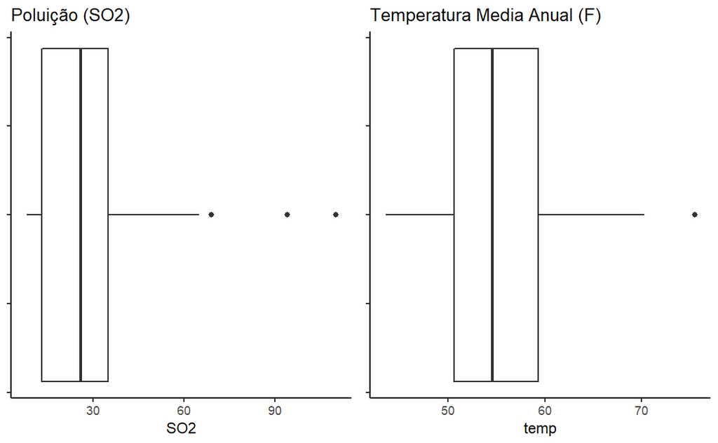

```r
plot1 = ggplot(dt,aes(y=SO2)) +
    geom_boxplot() +
    theme(legend.position="none") +
    ggtitle("Poluição (SO2)") +
    theme_classic() +
    coord_flip() +
    theme(axis.text.y = element_blank())

plot2 = ggplot(dt,aes(y=temp)) +
    geom_boxplot() +
    theme(legend.position="none") +
    ggtitle("Temperatura Media Anual (F)") +
    theme_classic() +
    coord_flip() +
    theme(axis.text.y = element_blank())

plot3 = ggplot(dt,aes(y=manu)) +
    geom_boxplot() +
    theme(legend.position="none") +
    ggtitle("Número de Empresas Manufatureiras") +
    theme_classic() +
    coord_flip() +
    theme(axis.text.y = element_blank())

plot4 = ggplot(dt,aes(y=popul)) +
    geom_boxplot() +
    theme(legend.position="none") +
    ggtitle("População em milhares (Censo 1970)") +
    theme_classic() +
    coord_flip() +
    theme(axis.text.y = element_blank())

plot5 = ggplot(dt,aes(y=wind)) +
    geom_boxplot() +
    theme(legend.position="none") +
    ggtitle("Velocidade Média Anual do vento (mi/hr)") +
    theme_classic() +
    coord_flip() +
    theme(axis.text.y = element_blank())

plot6 = ggplot(dt,aes(y=precip)) +
    geom_boxplot() +
    theme(legend.position="none") +
    ggtitle("Precipitação média anual (polegadas)") +
    theme_classic() +
    coord_flip() +
    theme(axis.text.y = element_blank())

plot7 = ggplot(dt,aes(y=predays)) +
    geom_boxplot() +
    theme(legend.position="none") +
    ggtitle("Número médio de dias com precipitação por ano") +
    theme_classic() +
    coord_flip() +
    theme(axis.text.y = element_blank())


grid.arrange(plot1,plot2,ncol=2)
```

### 3.1.2 Manu / Popul

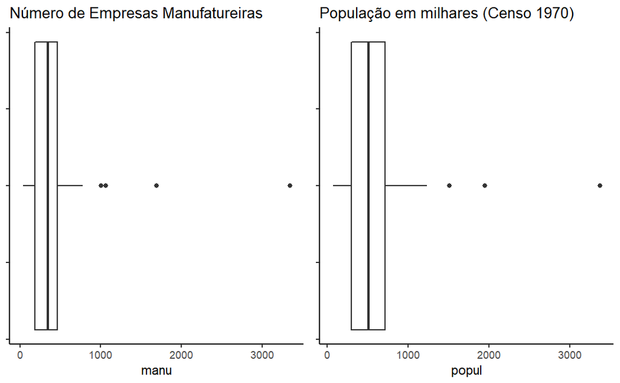

```r
grid.arrange(plot3,plot4,ncol=2)
```

### 3.1.3 Wind / Precip

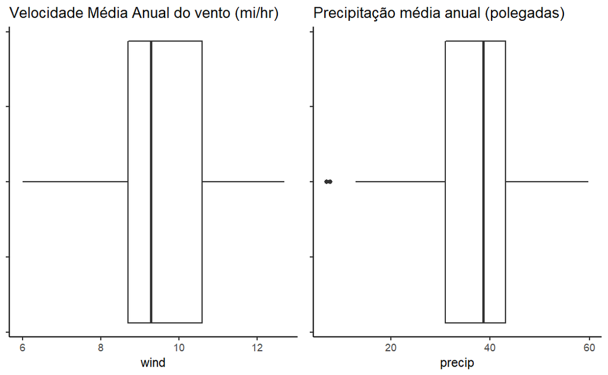

```r
grid.arrange(plot5,plot6,ncol=2)
```

### 3.1.4 Predays

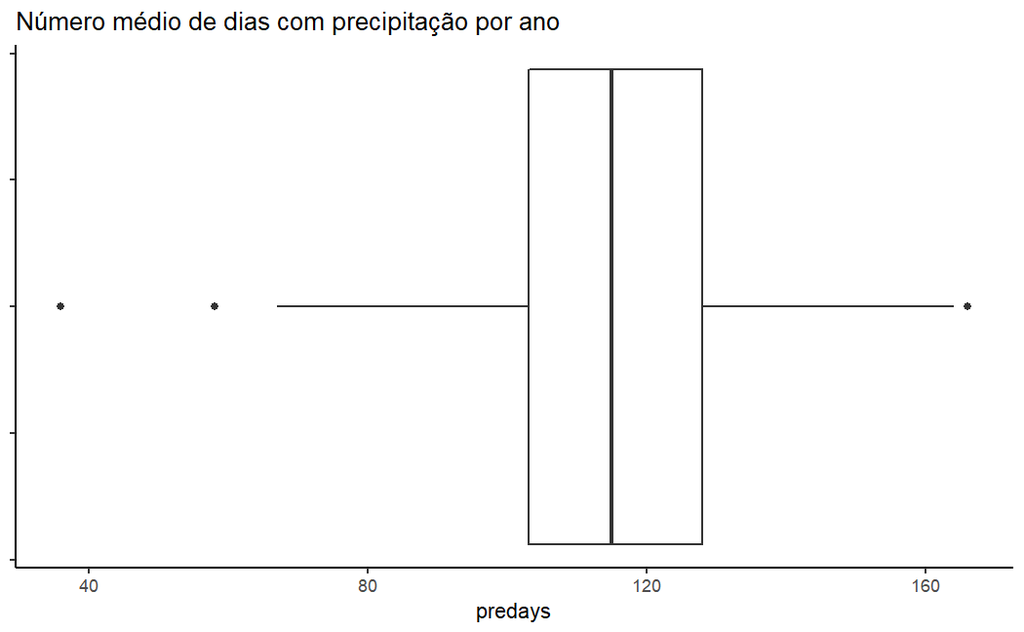

```r
grid.arrange(plot7)
```

## 3.2 Correlação entre as variáveis

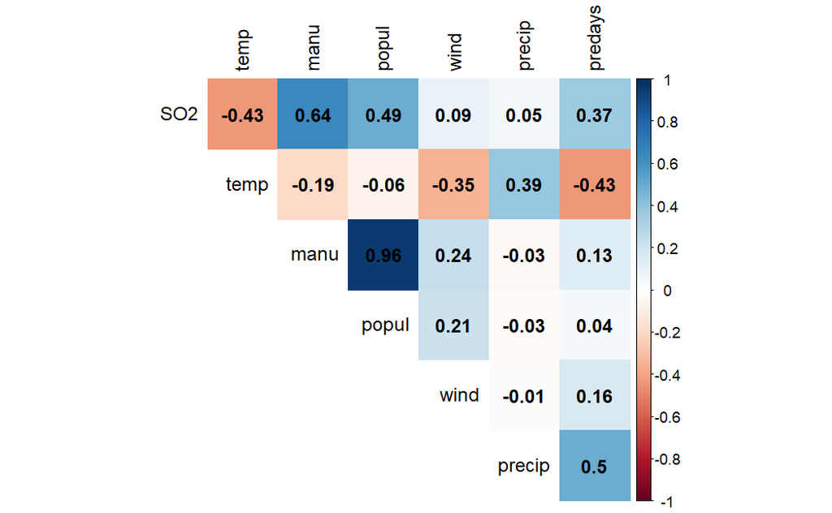

```r
corrplot(cor(dt[,-c(1)]),method = "color",
                    type="upper",
                    diag=FALSE,
                    addCoef.col="black",
                    tl.col="black")
```

Podemos observar uma forte correlação positiva entre o tamanho da população e o número de empresas manufatureiras. Normalmente quando temos duas variáveis com correlação muito alta, isso atrapalha nosso modelo, pois ambas tendem a explicar a mesma coisa. Porém para os métodos que utilizaremos não precisaremos nos preocupar com isso.

## 3.3 Testando a normalidade das variáveis

Utilizando o teste de hipóteses Shapiro-Wilk percebemos que a um nível de significância de 0.05 as variáveis Wind e Predays possuem Distribuição Normal, ou melhor, não há evidências para dizer que não possuem Distribuição Normal.

### 3.3.1 SO2

```r
shapiro.test(dt$SO2)
```

```
    Shapiro-Wilk normality test

data:  dt$SO2
W = 0.81165, p-value = 0.000009723
```

### 3.3.2 Temp

```r
shapiro.test(dt$temp)
```

```
    Shapiro-Wilk normality test

data:  dt$temp
W = 0.93554, p-value = 0.02215
```

### 3.3.3 Manu

```r
shapiro.test(dt$manu)
```

```
    Shapiro-Wilk normality test

data:  dt$manu
W = 0.60548, p-value = 0.000000002781
```

### 3.3.4 Popul

```r
shapiro.test(dt$popul)
```

```
    Shapiro-Wilk normality test

data:  dt$popul
W = 0.68049, p-value = 0.00000003623
```

### 3.3.5 Wind

```r
shapiro.test(dt$wind)
```

```
    Shapiro-Wilk normality test

data:  dt$wind
W = 0.98057, p-value = 0.6973
```

### 3.3.6 Precip

```r
shapiro.test(dt$precip)
```

```
    Shapiro-Wilk normality test

data:  dt$precip
W = 0.94214, p-value = 0.03725
```

### 3.3.7 Predays

```r
shapiro.test(dt$predays)
```

```
    Shapiro-Wilk normality test

data:  dt$predays
W = 0.9654, p-value = 0.2419
```

## 3.4 Dispersão 2 a 2 (Emissão de $S02$ como variável resposta)

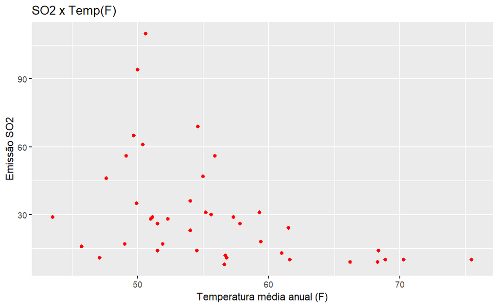

```r
ggplot(dt,aes(x=temp, y=SO2)) + geom_point(colour='red') + labs(x="Temperatura média anual (F)", y="Emissão SO2", title="SO2 x Temp(F)") + scale_x_continuous(breaks=seq(-100, 100, 10))
```

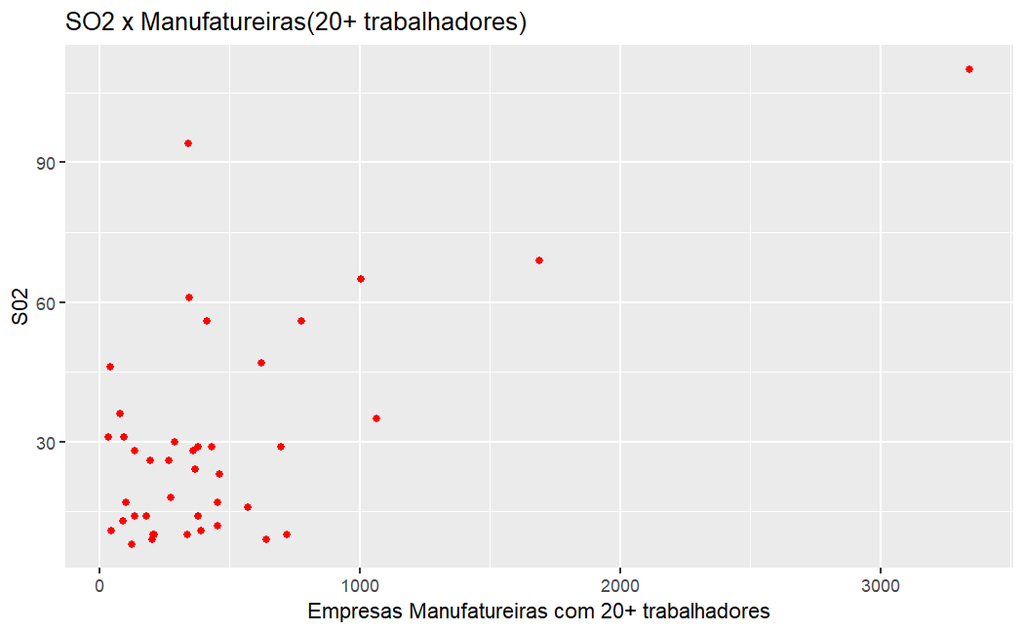

```r
ggplot(dt,aes(x=manu, y=SO2)) + geom_point(colour='red') + labs(x="Empresas Manufatureiras com 20+ trabalhadores", y="S02", title="SO2 x Manufatureiras(20+ trabalhadores)")
```

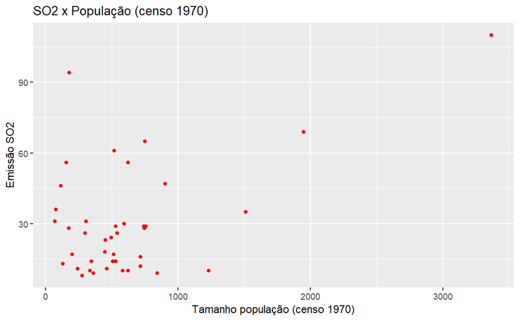

```r
ggplot(dt,aes(x=popul, y=SO2)) + geom_point(colour='red') + labs(x="Tamanho população (censo 1970)", y="Emissão SO2", title="SO2 x População (censo 1970)")
```

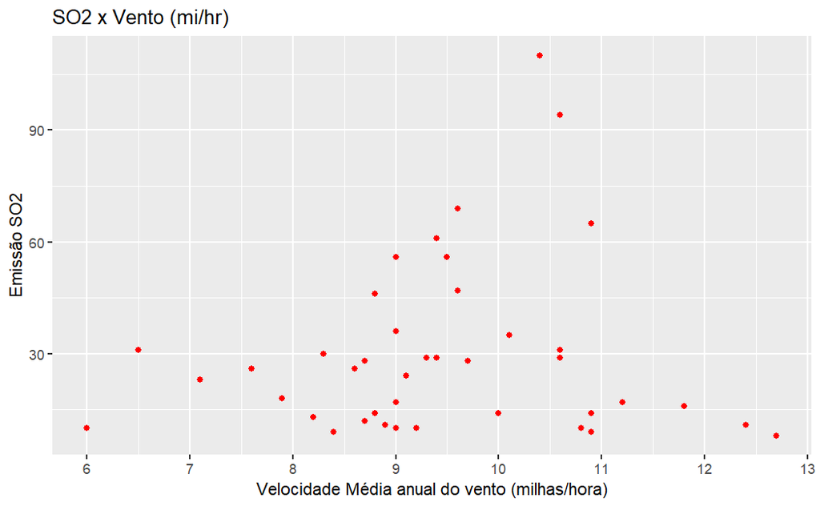

```r
ggplot(dt,aes(x=wind, y=SO2)) + geom_point(colour='red') + labs(x="Velocidade Média anual do vento (milhas/hora)", y="Emissão SO2", title="SO2 x Vento (mi/hr)") + scale_x_continuous(breaks=seq(0, 100, 1))
```

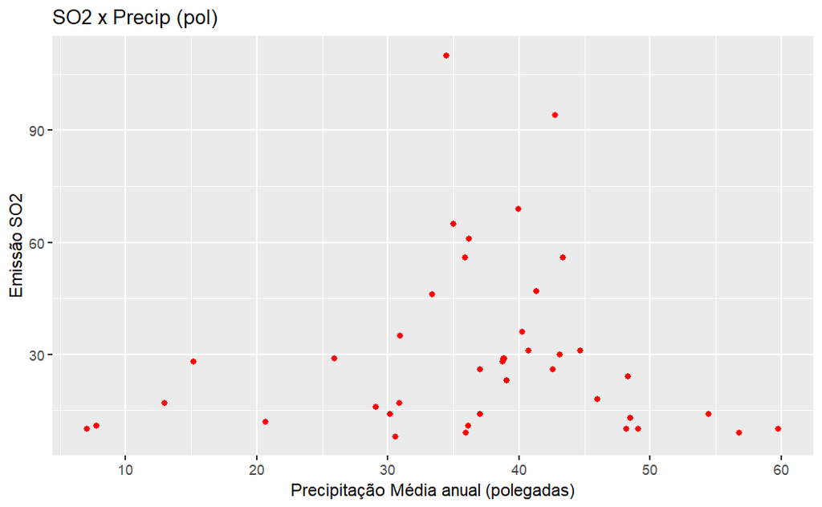

```r
ggplot(dt,aes(x=precip, y=SO2)) + geom_point(colour='red') + labs(x="Precipitação Média anual (polegadas)", y="Emissão SO2", title="SO2 x Precip (pol)") + scale_x_continuous(breaks=seq(0, 100, 10))
```

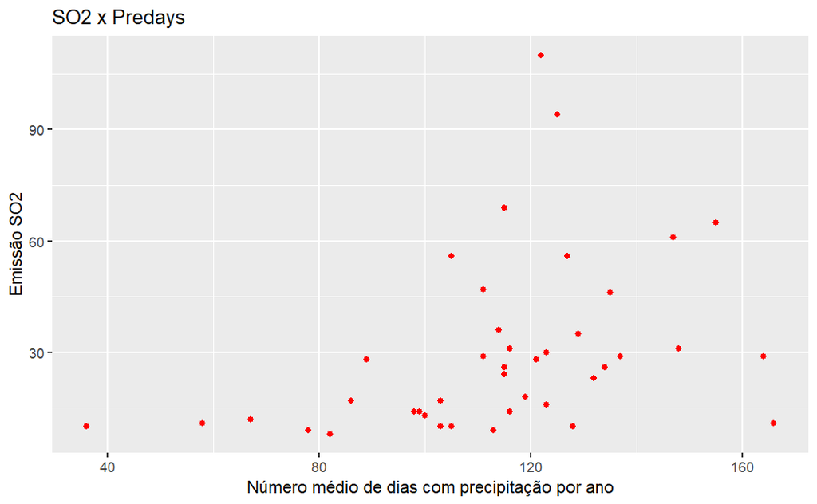

```r
ggplot(dt,aes(x=predays, y=SO2)) + geom_point(colour='red') + labs(x="Número médio de dias com precipitação por ano", y="Emissão SO2", title="SO2 x Predays")
```

Vejamos a seguir o plot de todas as combinações (2 a 2). Obs: Esperamos observar forte relação linear positiva de população x manufatureiras.

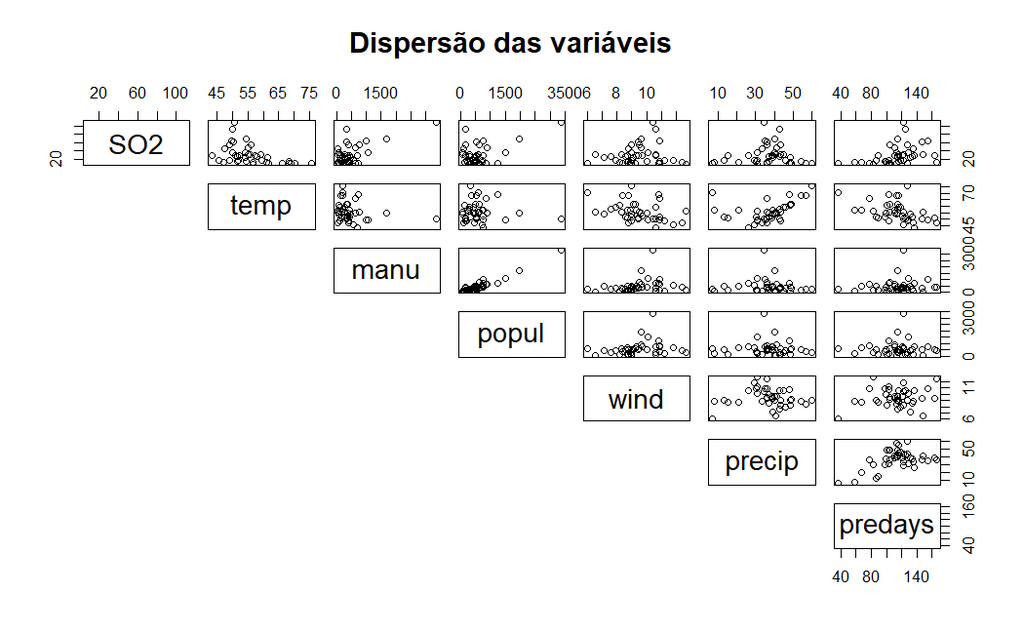

```r
plot(dt[,-c(1)],lower.panel=NULL,main="Dispersão das variáveis")
```

# 4 Adicionando variáveis espaciais

Para incrementar nosso dataset, vamos atrás de dados geográficos e procurar alguma relação da localização com o nível de poluição das cidades.

```r
us.cities <- read.csv2("aula_02/uscities.csv", sep =',', header=T)

head(us.cities)
```

|  | city | city_ascii | state_id | state_name | county_fips | county_name | lat | lng | population | density | source | military | incorporated | timezone | ranking | zips | id |
| --- | --- | --- | --- | --- | --- | --- | --- | --- | --- | --- | --- | --- | --- | --- | --- | --- | --- |
| 1 | New York | New York | NY | New York | 36061 | New York | 40.6943 | -73.9249 | 18713220 | 10715 | polygon | FALSE | TRUE | America/New_York | 1 | 11229 11226 11225 11224 11222 11221 11220 11385 10169 10168 10167 10165 10162 10282 10280 10040 10044 11109 11104 11105 11379 11378 11377 11697 11694 11692 11693 11691 10271 10279 10278 10075 10302 10… | 1840034016 |
| 2 | Los Angeles | Los Angeles | CA | California | 6037 | Los Angeles | 34.1139 | -118.4068 | 12750807 | 3276 | polygon | FALSE | TRUE | America/Los_Angeles | 1 | 90291 90293 90292 91316 91311 90037 90031 90008 90004 90005 90006 90007 90001 90002 90003 90710 90089 91344 91345 91340 91342 91343 90035 90034 90036 90033 90032 90039 90247 90248 91436 91371 91605 91… | 1840020491 |
| 3 | Chicago | Chicago | IL | Illinois | 17031 | Cook | 41.8373 | -87.6862 | 8604203 | 4574 | polygon | FALSE | TRUE | America/Chicago | 1 | 60018 60649 60641 60640 60643 60642 60645 60644 60647 60646 60616 60617 60614 60615 60612 60613 60610 60611 60618 60619 60827 60638 60639 60634 60636 60637 60630 60631 60632 60633 60605 60604 60607 60… | 1840000494 |
| 4 | Miami | Miami | FL | Florida | 12086 | Miami-Dade | 25.7839 | -80.2102 | 6445545 | 5019 | polygon | FALSE | TRUE | America/New_York | 1 | 33129 33125 33126 33127 33128 33149 33144 33145 33142 33139 33138 33137 33136 33135 33134 33133 33132 33131 33130 33150 33101 33109 33111 33151 33222 33231 33233 33238 33255 33299 | 1840015149 |
| 5 | Dallas | Dallas | TX | Texas | 48113 | Dallas | 32.7936 | -96.7662 | 5743938 | 1526 | polygon | FALSE | TRUE | America/Chicago | 1 | 75287 75098 75233 75254 75251 75252 75253 75032 75238 75232 75230 75231 75236 75237 75234 75235 75088 75087 75243 75246 75244 75249 75248 75051 75166 75210 75211 75212 75214 75215 75216 75217 75218 75… | 1840019440 |
| 6 | Philadelphia | Philadelphia | PA | Pennsylvania | 42101 | Philadelphia | 40.0077 | -75.1339 | 5649300 | 4554 | polygon | FALSE | TRUE | America/New_York | 1 | 19154 19151 19150 19153 19152 19102 19103 19106 19107 19104 19109 19128 19129 19120 19121 19122 19123 19124 19125 19126 19127 19112 19111 19115 19114 19116 19119 19118 19148 19149 19146 19147 19144 19… | 1840000673 |

```r
# Confirmando que todas as cidades do nosso dt estão em us.cities.
corresp_city = sapply(dt$city, function(z) {
    sum(us.cities$city %in% z)
})
corresp_city[corresp_city == 0]
```

```
named integer(0)
```

```r
# Excluindo cidades que não nos interessam
us_dt = us.cities[us.cities$city %in% dt$city, ]
```

Ao tentar juntar os datasets podemos observar que existem diversas cidades homonimas (com mesmo nome), por exemplo, existem 34 cidades denominadas Albany. Escolheremos arbitrariamente (com o fim de conseguirmos concluir nosso trabalho) as cidades com maior população.

```r
#Criando ID
us_dt$id = 1:nrow(us_dt)

#Criando a função para identificar o ID com maior população
get_max = function(z) {
    s = us_dt[us_dt$city %in% z, ]
    s$id[which.max(s$pop)]
}

# aplicando a função as cidades em dt
id_max_pop = apply(data.frame(dt$city), 1, get_max)

# selecionando os registros (linhas) com as correspondencias
us_dt = us_dt[id_max_pop, ]

# Selecionando apenas as variáveis que nos interessam

us_dt = us_dt[c("city","lat","lng")]

# Transformando lat e lng em números

us_dt$lat <- as.numeric(us_dt$lat)
us_dt$lng <- as.numeric(us_dt$lng)
```

Com os dados tratados, podemos unir nossos nossos datasets.

## 4.1 Tabela com dados geográficos

```r
dt_cities <- left_join(dt, us_dt)
dt_cities
```

| city | SO2 | temp | manu | popul | wind | precip | predays | lat | lng |
| --- | --- | --- | --- | --- | --- | --- | --- | --- | --- |
| Albany | 46 | 47.6 | 44 | 116 | 8.8 | 33.36 | 135 | 42.6664 | -73.7987 |
| Albuquerque | 11 | 56.8 | 46 | 244 | 8.9 | 7.77 | 58 | 35.1053 | -106.6464 |
| Atlanta | 24 | 61.5 | 368 | 497 | 9.1 | 48.34 | 115 | 33.7627 | -84.4224 |
| Baltimore | 47 | 55.0 | 625 | 905 | 9.6 | 41.31 | 111 | 39.3051 | -76.6144 |
| Buffalo | 11 | 47.1 | 391 | 463 | 12.4 | 36.11 | 166 | 42.9016 | -78.8487 |
| Charleston | 31 | 55.2 | 35 | 71 | 6.5 | 40.75 | 148 | 32.8153 | -79.9628 |
| Chicago | 110 | 50.6 | 3344 | 3369 | 10.4 | 34.44 | 122 | 41.8373 | -87.6862 |
| Cincinnati | 23 | 54.0 | 462 | 453 | 7.1 | 39.04 | 132 | 39.1413 | -84.5061 |
| Cleveland | 65 | 49.7 | 1007 | 751 | 10.9 | 34.99 | 155 | 41.4767 | -81.6804 |
| Columbus | 26 | 51.5 | 266 | 540 | 8.6 | 37.01 | 134 | 39.9862 | -82.9850 |

[output cut: 31 more lines]

## 4.2 Mapa

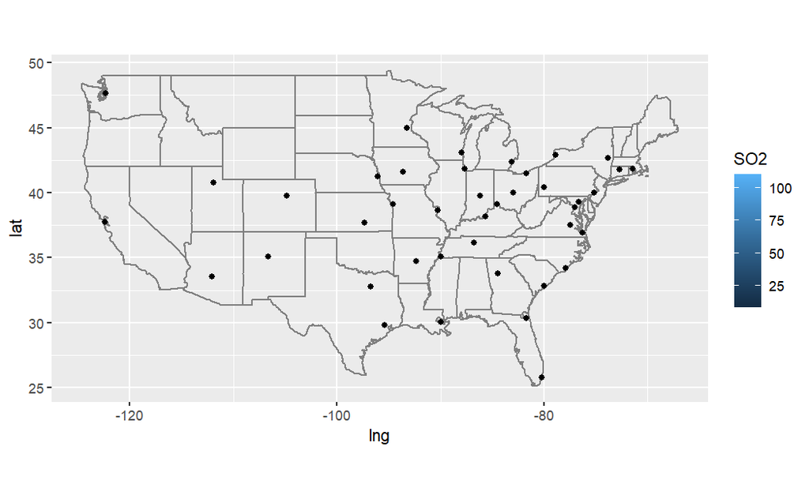

```r
library(ggrepel)

ggplot(dt_cities, aes(lng, lat, group, fill=SO2)) + borders("state") + coord_quickmap() + geom_point() + geom_label_repel(aes(label = city), size = 2)
```

Plotando novamente o mapa, agora com a visualização do grau de poluíção.

[figure not shown]

```r
ggplot(dt_cities, aes(lng, lat, group, fill=SO2)) + borders("state") + coord_quickmap() + geom_point() + geom_label_repel(aes(label = SO2), size = 2)
```

# 5 PCA

```r
dt_cities_pca <- dt_cities[,-c(2,9,10)]
rownames(dt_cities_pca) <- dt_cities_pca$city
dt_cities_pca <- dt_cities_pca[,-c(1)]
```

```r
# Padronizamos as variáveis, afinal já foi possível perceber que estão em escalas bem diferentes, o que prejudicaria nossa análise.

pr.out=prcomp(dt_cities_pca, scale=TRUE, center=TRUE)
```

## 5.1 Vetores de carga (“Betas” da combinação linear de cada componente)

```r
pr.out$rotation
```

```
                PC1        PC2         PC3         PC4         PC5         PC6
temp     0.32964613 -0.1275974  0.67168611 -0.30645728 -0.55805638  0.13618780
manu    -0.61154243 -0.1680577  0.27288633  0.13684076  0.10204211  0.70297051
popul   -0.57782195 -0.2224533  0.35037413  0.07248126 -0.07806551 -0.69464131
wind    -0.35383877  0.1307915 -0.29725334 -0.86942583 -0.11326688  0.02452501
precip   0.04080701  0.6228578  0.50456294 -0.17114826  0.56818342 -0.06062222
predays -0.23791593  0.7077653 -0.09308852  0.31130693 -0.58000387  0.02196062
```

Como analisar a tabela acima:

PC1 $\cong$ 0.32 $\times$ temp $-$ 0.61 $\times$ manu $-$ 0.57 $\times$ popul $-$ 0.35 $\times$ wind $+$ 0.04 $\times$ precip $-$ 0.23 $\times$ predays

```r
# Apenas para fins de conferência
eigen(cor(dt_cities_pca))$vectors
```

## 5.2 Descrição de cada componente

```r
summary(pr.out)
```

```
Importance of components:
                         PC1   PC2    PC3    PC4    PC5     PC6
Standard deviation     1.482 1.225 1.1810 0.8719 0.3385 0.18560
Proportion of Variance 0.366 0.250 0.2324 0.1267 0.0191 0.00574
Cumulative Proportion  0.366 0.616 0.8485 0.9752 0.9943 1.00000
```

Podemos observar que utilizando apenas as componentes 1, 2 e 3 somos capazes de explicar 84,85% da variância de nossos dados. E apenas com 4 componentes explicamos 97.52% da variância dos dados! Por tanto não parece razoável utilizarmos PC5 e PC6.

Para melhor visualização:

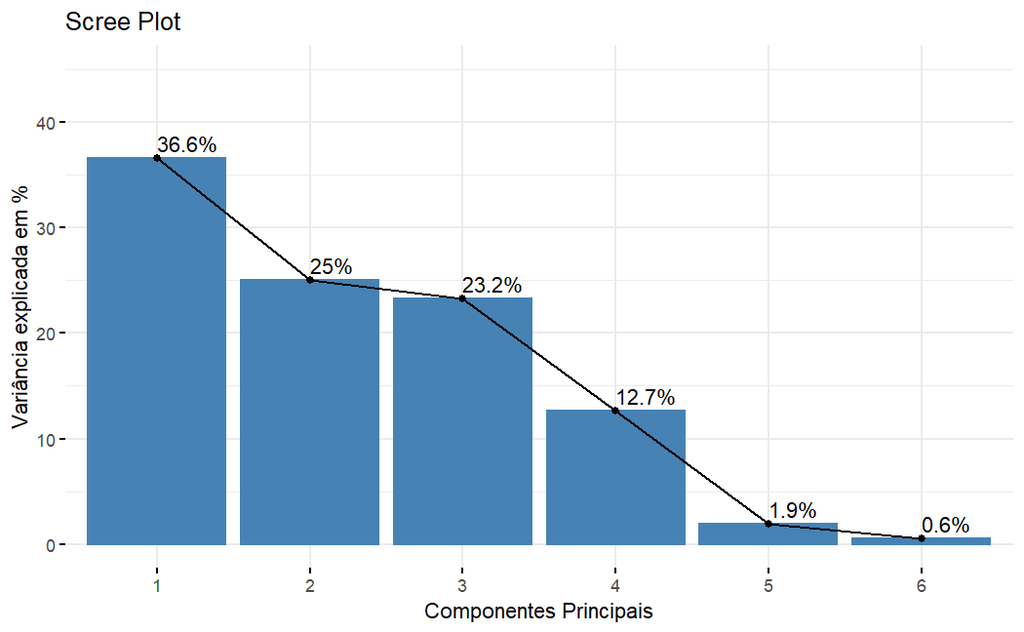

```r
library(factoextra)
  fviz_eig(pr.out, addlabels = TRUE, ylim=c(0,45)) + labs(title ="Scree Plot", x = "Componentes Principais", y = "Variância explicada em %")
```

```r
head(pr.out$x)
```

```
                   PC1         PC2         PC3         PC4         PC5         PC6
Albany       0.5323325  0.78235037 -1.34588548  0.87190217  0.04566668 -0.06180699
Albuquerque  1.3997048 -2.83072462 -1.25975067 -0.09480763 -0.23977116  0.03021140
Atlanta      0.5916448  0.58003001  0.98319718 -0.22635049  0.11664958  0.05874224
Baltimore   -0.5031297  0.02840114  0.35913801 -0.08632242  0.31862529 -0.19102895
Buffalo     -1.3736443  1.85722898 -1.75439732 -0.84593975 -0.73067753  0.01877450
Charleston   1.4122097  1.19572930  0.07846869  1.98678170 -0.28211174  0.05737416
```

## 5.3 Gráfico das Variáveis

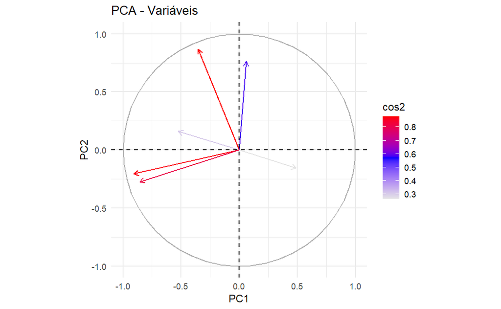

```r
fviz_pca_var(pr.out, repel = TRUE,
col.var = "cos2",
gradient.cols = c("#E5E5E5", "blue", "red"),
select.ind = list(cos2 = 15)
) + theme_minimal() + labs(title ="PCA - Variáveis", x = "PC1", y = "PC2")
```

O gráfico acima mostra a relação entre todas as variáveis. Porém, perceba que as variáveis “temp” e “wind” não são bem representadas por PC1 e PC2. Vejamos abaixo um gráfico que mostra o quanto cada uma das variáveis contribuiu (em %) para as duas primeiras componentes.

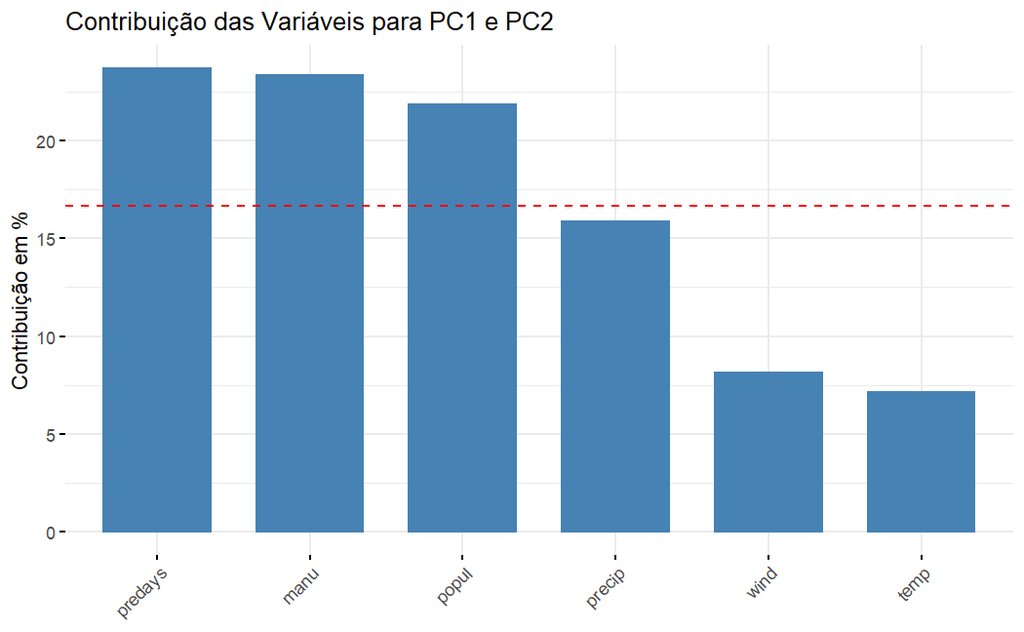

```r
fviz_contrib(pr.out, choice = "var", axes = 1:2) + labs(title ="Contribuição das Variáveis para PC1 e PC2", y = "Contribuição em %")
```

## 5.4 Gráfico dos Indivíduos

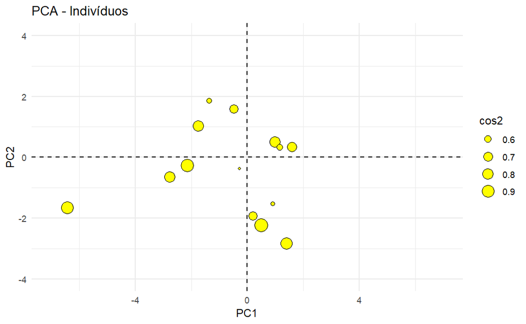

```r
fviz_pca_ind(pr.out, repel = TRUE,
pointsize = "cos2",
pointshape = 21,
fill = "yellow",
select.ind = list(cos2 = 15)
) + theme_minimal() + labs(title ="PCA - Indivíduos", x = "PC1", y = "PC2") + xlim(-7, 7) + ylim (-4, 4)
```

O gráfico acima representa bem as diferenças entre os indivíduo, quanto mais distantes mais diferentes são entre si. O gráfico mostra apenas as 15 cidades mais bem representadas por PC1 e PC2. Juntemos então tudo em apenas um gráfico para melhor visualização do porquê essas cidades são tão diferentes (ou parecidas).

## 5.5 Gráfico Indivíduos + Variáveis (Biplot)

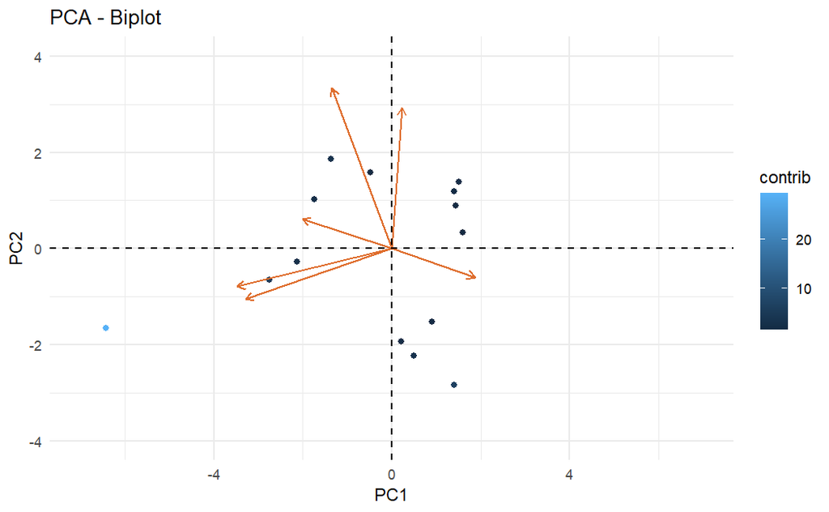

```r
fviz_pca_biplot(pr.out, repel = TRUE,
col.var = "#df6e2e",
col.ind = "contrib",
pointsize = 1.5,
select.ind = list(contrib = 15)
) + theme_minimal() + labs(title ="PCA - Biplot", x = "PC1", y = "PC2") + xlim(-7, 7) + ylim (-4, 4)
```

Em uma rápida análise podemos dizer, por exemplo, que a distância entre Chigado e Miami é explicada principalmente por sua diferença em termos de população e número de empresas manufatureiras. Podemos dizer também que chove muito mais em Miami. Vale a pena ressaltar que estamos utilizando apenas as componentes 1 e 2, e que contribuição de Chigado se destaca para formação dessas componentes.

## 5.6 Cos2 - PC1, PC2, PC3

Já percebemos que tanto a variável vento quanto temperatura não foram bem representadas em PC1 e PC2. O que aconteceria se adicionassemos PC3 a nossa análise?

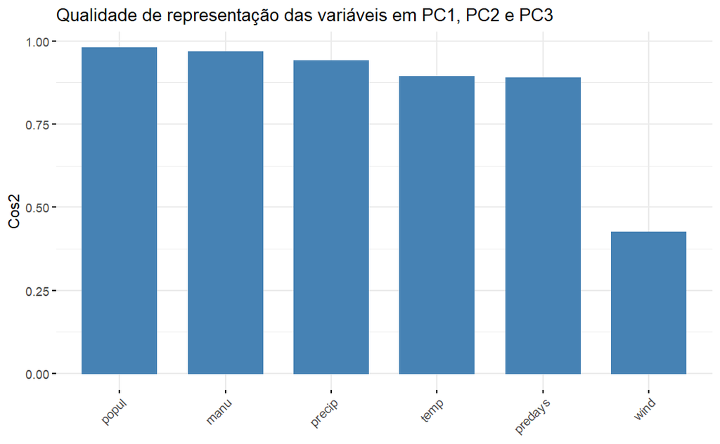

```r
fviz_cos2(pr.out, choice = "var", axes = 1:3) + labs(title ="Qualidade de representação das variáveis em PC1, PC2 e PC3", y = "Cos2")
```

Agora temos temperatura bem representada. Lembrando que ao utilizarmos PC1+PC2+PC3 explicamos aproximadamente 84,85% dos dados. O ideal então seria incluírmos PC4 em nossa análise. Será que conseguiriamos então uma boa representação para o vento?

Vejamos então a contribuição de cada uma de nossas variáveis para cada uma das componentes. Vale lembrar que as variáveis que mais contribuem para as primeiras componentes são as variáveis mais importantes para explicar a variabilidade dos dados, por tanto não há necessariamete problema em deixar algumas variáveis com pouca representação, se fosse o caso.

## 5.7 Contribuição das variáveis para cada componente

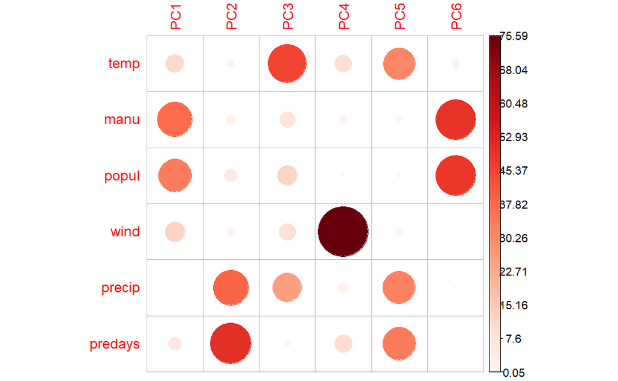

```r
var=get_pca_var(pr.out)
colnames(var$contrib) = c("PC1","PC2","PC3","PC4","PC5","PC6")
reds=COL1(sequential = "Reds")
corrplot(var$contrib, is.corr=FALSE, col = reds)
```

Podemos então concluir que ao incluirmos PC4 em nossa análise teremos uma boa representação de todas as novas variáveis, além de conseguirmos explicar aproximadamente 97.52% da variância do nosso dataset!

# 6 MDS

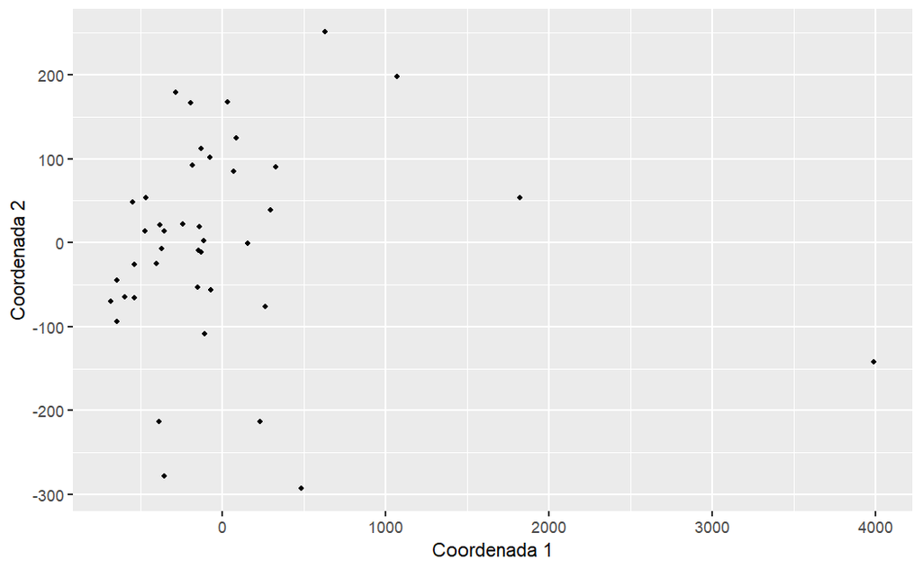

```r
mds_nonstand <- dt_cities_pca %>% dist() %>% cmdscale(k=6,eig=TRUE)
mds_ns <- as.data.frame(mds_nonstand$points)
mds_ns$city <- rownames(mds_ns)

ggplot(mds_ns, aes(x=V1, y=V2)) + geom_point(size=1) + labs(x="Coordenada 1",y="Coordenada 2") + geom_label_repel(mapping = aes(label = city))
```

A distancia entre as variáveis representa o quão diferentes elas são entre si. Como podemos observar Philadelfia e Chigado se destacam. É possível que apenas uma ou outra variável tenha criado essa distância, por conta da escala. Portanto, padronizaremos todas as variáveis para uma escala [0,1] e repetiremos nossa análise, fazendo então com que todas as variáveis tenham o mesmo peso.

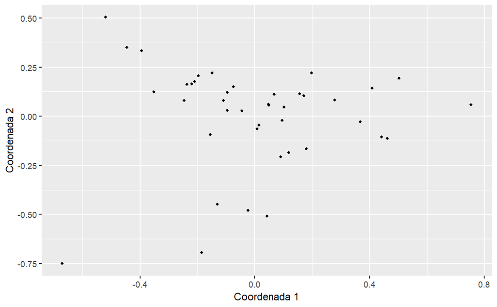

```r
dt_cities_stand = apply(dt_cities_pca, FUN = function(x) {(x-min(x)) / (max(x)-min(x))}, MARGIN = 2)
mds_stand <- dt_cities_stand %>% dist() %>% cmdscale(k=6,eig=TRUE)
mds_s=as.data.frame(mds_stand$points)
mds_s$city <- rownames(mds_s)

ggplot(mds_s, aes(x=V1, y=V2)) + geom_point(size=1) + labs(x="Coordenada 1",y="Coordenada 2") + geom_label_repel(mapping = aes(label = city))
```

Podemos observar mudança significativa nas distancias entre as cidades. Chicago parece ainda se destacar, mas agora com destaque para Phoenix. Percebam também que Philadelphia não se destaca mais das demais cidades.

## 6.1 Criando Clusters (K-means)

Utilizaremos uma técnica de clusterização para tentarmos separar as cidades em 3 grupos. A técnica utilizada será o K-means.

### 6.1.1 Dados não padronizados

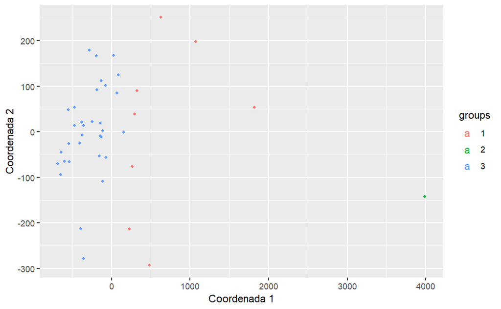

```r
clust_ns <- kmeans(mds_ns[,-c(7)], 3)$cluster %>% as.factor()
mds_ns <- mds_ns %>% mutate(groups = clust_ns)

ggplot(mds_ns, aes(x=V1, y=V2, color = groups)) + geom_point(size=1) + labs(x="Coordenada 1",y="Coordenada 2") + geom_label_repel(mapping = aes(label = city))
```

Podemos observar que chigado faz parte de um grupo só seu, vamos ver se a análise com os dados padronizados mudaria essa perspectiva.

### 6.1.2 Dados Padronizados

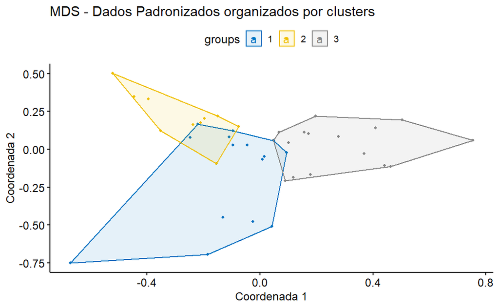

```r
clust_s <- kmeans(mds_s[,-c(7)], 3)$cluster %>% as.factor()
mds_s <- mds_s %>% mutate(groups = clust_s)

ggscatter(mds_s, x = "V1", xlab="Coordenada 1", y = "V2",ylab="Coordenada 2",
          label = rownames(dt_cities_stand),
          title = "MDS - Dados Padronizados organizados por clusters",
          color = "groups",
          palette = "jco",
          size = 1,
          ellipse = TRUE,
          ellipse.type = "convex",
          repel = TRUE)
```

A análise com os dados padronizados me parece mais razóavel e portanto daqui para frente utilizaremos apenas eles.

# 7 TSNE

```r
tsne_fit <- dt_cities_stand %>% Rtsne(perplexity=13)
tsne_df <- tsne_fit$Y %>% as.data.frame() %>% rename(Coord1="V1", Coord2="V2")
tsne_df$city <- rownames(dt_cities_stand)


ggplot(data=tsne_df, aes(x=Coord1, y=Coord2)) + geom_point() + geom_label_repel(mapping = aes(label = city)) + labs(x="Coordenada 1",y="Coordenada 2")

#tsne_fitteste <- dt_cities_stand %>% Rtsne(perplexity=13)
#tsne_dfteste <- tsne_fitteste$Y %>% as.data.frame() %>% rename(Coord1="V1", Coord2="V2")
#tsne_dfteste$city <- rownames(dt_cities_stand)
#ggplot(data=tsne_dfteste, aes(x=Coord1, y=Coord2)) + geom_point() + geom_label_repel(mapping = #aes(label = city)) + labs(x="Coordenada 1",y="Coordenada 2")
```

[output not shown]

```r
tsne_df$groups <- mds_s$groups

ggplot(data=tsne_df, aes(x=Coord1, y=Coord2, col=groups)) + geom_point() + geom_label_repel(mapping = aes(label = city)) + labs(x="Coordenada 1",y="Coordenada 2")
```

[output not shown]

# 8 Comparando com SO2

Adicionando o nível de poluição de volta ao dataset, e analisando se nossos grupos nos dizem algo sobre o nível de S02.

```r
tsne_df$SO2 <- dt_cities$SO2

ggplot(data=tsne_df, aes(x=Coord1, y=Coord2, col=groups)) + geom_point() + geom_label_repel(mapping = aes(label = SO2)) + labs(x="Coordenada 1",y="Coordenada 2")
```

[output not shown]

Por fim, vamos comparar como se comporta os níveis de poluição dentro de cada grupo.

```r
ggplot(tsne_df, aes(x=groups, y=SO2, col=groups)) + stat_boxplot() + stat_summary(fun=mean, geom="point", shape=8, size=5, color="red", fill="red")
```

[output not shown]

# 9 Conclusão

Conseguimos fazer algumas análises bem interessantes no dataset. Com o PCA conseguimos diminuir nossas dimensões de 6 para 4 e ainda assim explicar mais de 90% da variabilidade de nossos dados. Com o MSD e TSNE conseguimos uma representação espacial interessante de nossos indivíduos e até mesmo enxergar uma relação com os níveis de SO2.

As análises poderiam ser melhores se disponibilizassemos de um dataset com mais observações, mais atual (acredito que hoje existam formas mais precisas de medir cada uma das variáveis) e se tivessemos um background melhor sobre o tema, assim poderiamos até mesmo incluir outras covariaveis. Obviamente a análise também será melhor conforme formos aprendendo novas técnicas na disciplina de Análise Multivariada.